# Stories and technology

2020-04-30

We use words to communicate and inevitably words result in stories. Stories make technology useful and only with stories does technology have meaning. It’s the stories we tell that make technology possible.

To know how something works, in the end, means to know its purpose. And this purpose is a story. In the end, exaggerated while still true, all things, also abstractions must be understood as stories.

This is at least how, though simplified and freely interpreted, the German philosopher Martin Heidegger would have it. I like this idea, not everyone does. But it is an idea of Heidegger (although we can always predate things in the history of ideas) who had a major impact on a variety of thinkers in subjects such as sociology and anthropology but also linguistics.

A related idea is that technology acts as an enhancement of our cognitive and physical abilities. It makes us more able. In this view of Heidegger, it is when we fail, we get the tools to advance, when we realize we would be better off with a hat on the nail when hammering on it, so to speak.

Innovation comes from failure, or rather… from failing and in some sense — however unrelated — make something good come from it.

One example of how storytelling relates to technology is the aeolipile by Heron of Alexandria, constructed about a century AD.

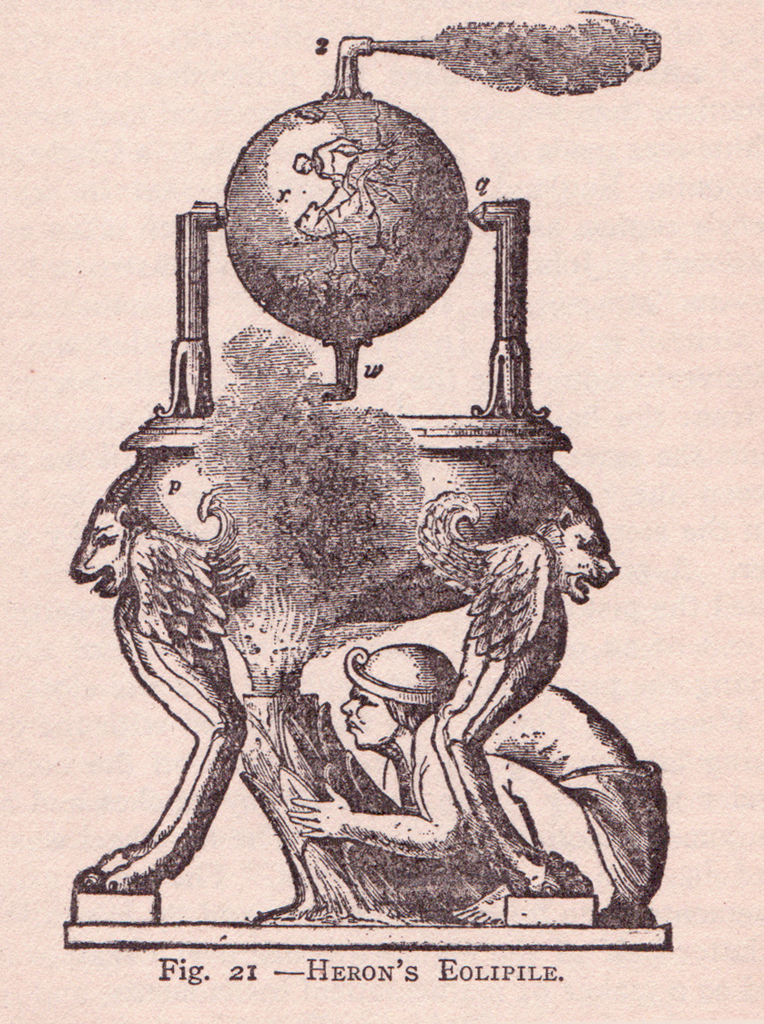

Aeolipile by Heron of Alexandria

This device was intended for cool effects, not to work as a steam-engine, driving locomotives, boats, and so on. In principle, everything was at hand but not until this engine was provided another story humanity began to use this for fueling means of transportation.

There are quite a few examples of how advanced technology of old was toys for the privileged few.

When people speak about things becoming mainstream we should always keep in mind, that this often is a story with a power far exceeding the original. That reading became mainstream is due to the printing press. This, in turn, made the world as we know it today possible.

Stories give us motifs and purpose and this is why technology as such is meaningless. Without stories, no technology is possible and such artifacts would be experienced as just random. A theme often explored in works of science fiction is the meeting with an ancient civilization whose technology is incomprehensible for us, a technology we don't understand and therefore can't do things with. A technology without action.

As a side note, the battle about the Web is a battle about myths, dreams, hopes, and fears. We can think that the Web is doomed to vanish soon. Who would want to deal with a medium mainly made for text? Even with images, sound, and video, we're stuck with a flattened world similar to a book page. It doesn't matter if images are 2- or 3d. Virtual Reality, a technology not yet mainstream, a technology still needing stories, in the true sense will not take place on the Web as we know it, or the Web will be something else. Virtual Reality still needs powerful stories.

My hope is that the old Web will stick around. Flatness sometimes has a greater depth. It is perhaps unlikely, but not unthinkable, that the Web would be around 50 years from now. We would need stories to make it happen.

What does it do? What does the Web do? What is the principle that drives it? What does it want? What does the Web hope and dream of?

The Web doesn't do anything. It's here you and I come into the picture.

The Web will never be better than you and me. What we use it for, determine the essence of it. In itself a web stretching worldwide is pointless. We should use it as a toy, but we should also use it to do business, to discuss, hang out, make new friends and loved ones.

And because of this — this is what the proponents of censorship don't get — we will also make new enemies, steal and destroy. This is what we should not do. But still, any platform that allows the freedom to do business, discuss and make friends will always also need to have room for bad sentiments. This is why we have laws and morality.

There is not a single entity thought up by humanity that in the end is not part of some story.

The key is used to open the lock — on a door — situated in a wall — forming a house — on a property — owned by someone who bought it with money, perhaps for good and bad the most powerful story ever told by mankind) — following regulations on how to purchase things. But another story would be the use of the key when we deal with criminals or with people thought of as harmful to themselves or others.

Would someone have invented the key/lock if it had no meaning? No, why would s/he.

Say s/he did it as exercise. Still meaningful. But the purpose would be another, perhaps to see if s/he could bring about a system with moving parts with two modes (one in which some parts do not move, one in which they do).

But already now we are seeing a lock in our head? We are very much locked in how we think about this. A new story could unlock some other meaning of the very same device. This is why we need UX that enable us, provide us with environments in which we are free to be creative.

[About](https://bergsans.github.io/about) | [Archive](https://bergsans.github.io/essays)